# Analyze modeling results for *Salmonella typhimurium*

x86_64-conda-linux-gnu

04 August, 2026

# Background

## Coarse-grained cellular economy model

This notebook analyzes predictions from a *Salmonella typhimurium* coarse-grained cellular economy model. The goal is to derive insights into the optimal allocation of protein resources. A focus of this analysis is the cost and benefit of the flagellum, an immense protein machinery which consumes both protein resources (10,000s of subunits) and ATP-derived rotational energy. We hypothesize that the cost of the flagellum machinery must be offset by an important benefit, such as increased motility in the gut lumen, and/or ability to break free from trapped states in the mucosa. The functional groups we are interested in are major protein sectors such as:

- carbon and nutrient import (“Tra”)
- carbon metabolism to produce precursors such as Acetyl-CoA (“Cbn”)
- amino acid biosynthesis (“Aab”)
- translation and protein homeostasis (“Rib”)
- lipid and cell wall component biosynthesis (“Lpb”)
- Electron transport chain to re-generate ATP (“Etc”)
- Flagella and related motility proteins (“Fla”)
- All other proteins, which are not directly related to above groups (“Oth”)

## Mutant strains used for modeling

- `EM16223`: △flhDC, 0 flagella (null mutant)
- `EM16224`: motB D33N (rotation-deficient mutant)
- `EM9662`: Ppro1-flhDC, 0-1 flagellum
- `EM9661`: PproA-flhDC, mostly 1 flagellum
- `TH9677`: **WT**, 3-4 flagella on average
- `TH5861`: **WT**, (fliC ON background, for comparison to motB mutant)
- `EM9660`: PproB-flhDC, 5-6 flagella
- `EM8513`: PproD-flhDC, 7-8 flagella

# Prerequisites

- load required packages
- either download and install in RStudio or set up an appropriate conda environment

```r
suppressPackageStartupMessages({
  library(tidyverse)
  library(ggpubr)
  library(ggrepel)
  library(grDevices)
  library(ggh4x)
  library(colorspace)
})
```

Define global figure style, default colors, and a plot saving function (hidden chunk).

## Data import

- define order of sectors, strains, and mutants for plotting
- import experimental mass fraction data for KO strains

```r
sectors_sorted <- c("Oth", "Rib", "Cbn", "Aab", "Etc", "Lpb", "Fla", "Tra")
strains_sorted <- c("EM16223", "EM9662", "EM9661", "TH9677", "EM9660", "EM8513", "TH5861", "EM16224")
mutants_sorted <- c("ΔflhDC", "Ppro1-flhDC", "PproA-flhDC", "WT", "PproB-flhDC", "PproD-flhDC", "WT-(fliC ON)", "motB-D33N")
linebreak <- function(x) {
  str_replace(x, "-", "-\n")
}

df_mass_frac <- read_tsv("../tables/sector_mass_fractions.tsv", show_col_types = FALSE) %>%
  mutate(
    sector_short = factor(sector_short, levels = sectors_sorted),
    mutant = factor(mutant, levels = mutants_sorted)
  )
```

# Cell economy model

- the model was fitted with proteomics data for one single condition, the flagella null mutant (`EM16223`) with saturated substrate concentration
- all other predictions for different amounts of flagella, different substrate concentrations, and +/- ATP consumption were then solely obtained by model simulation without additional training data
- the parameters that are adjusted in model fitting process were the enzymatic properties `kcat` and `Km` for the 8 enzymes
- these were fitted by choosing reasonable starting ranges (see table `models/salmonella/parameters.csv`), followed by randomly sampled variation around the starting value (+/- 50% )
- random sampling was performed up to 1000 times and the parameter set with least error waws chosen for all further simulations

## Modeling results (steady state)

- different types of simulations were carried out:
  - **steady state simulation** where maximal growth rate was the objective, achieved by optimizing protein concentrations
  - different amounts of flagella were simulated similar to the range observed in mutants (0-5% forced protein investment)
  - **dynamic simulation** where also growth was maximized, but *over time* and with the goal to *move up a substrate gradient*
  - different amounts of flagella demonstrate the trade-off between growth-rate and motility

### Simulation of substrate limitation

- substrate concentration was increasing over time
- time has no particular meaning here, this is just a convention of the model
- first we create a function to import and merge multiple tables from model simulations

```r
read_model_results <- function(input_files) {
  lapply(
    input_files,
    function(x) {
      read_csv(x, show_col_types = FALSE, col_select = c(-1)) %>%
        filter(time != 0)
    }
  ) %>%
    setNames(str_extract(input_files, "flag_[0-9]\\.[0-9]+(\\_no)?(\\_ATP)?")) %>%
    bind_rows(.id = "simulation") %>%
    select(-matches("(^slk\\_)|(^p[0-9]$)|^v\\_ex|^c\\_")) %>%
    pivot_longer(
      cols = matches("^[av]\\_(tra|cbn|etc|aab|rib|lpb|fla|oth)"),
      names_to = c("variable", "sector_short"),
      names_pattern = "(.*)\\_(.*)",
      values_to = "value"
    ) %>%
    mutate(
      sector_short = factor(
        str_to_title(sector_short),
        levels = sectors_sorted
      ),
      flagella = as.numeric(str_extract(simulation, "[0-9]\\.[0-9]+"))
    )
}

df_model_sublim <- read_model_results(
  list.files("../../results/salmonella/c_limitation", pattern = ".csv", full.names = TRUE)
)
```

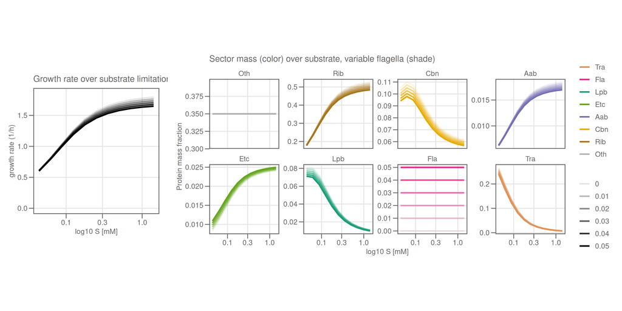

```r
plot_model_sublim <- ggarrange(
  ncol = 2, widths = c(0.27, 0.73),
  df_model_sublim %>%
    filter(variable == "a", sector_short == "Rib") %>%
    ggplot(aes(x = cex, y = mu, alpha = factor(flagella))) +
    geom_line() +
    custom_theme() +
    scale_color_manual(values = rev(custom_colors)) +
    scale_x_continuous(trans = "log10") +
    coord_cartesian(ylim = c(0, 1.85)) +
    labs(
      title = "Growth rate over substrate limitation",
      x = "log10 S [mM]",
      y = "growth rate (1/h)"
    ) +
    theme(legend.position = "none", aspect.ratio = 1),
  df_model_sublim %>%
    filter(variable == "a") %>%
    ggplot(aes(x = cex, y = value, color = fct_rev(sector_short), alpha = factor(flagella))) +
    geom_line() +
    custom_theme() +
    scale_color_manual(values = rev(custom_colors)) +
    scale_x_continuous(trans = "log10") +
    labs(
      title = "Sector mass (color) over substrate, variable flagella (shade)",
      x = "log10 S [mM]",
      y = "Protein mass fraction"
    ) +
    theme(legend.position = "right", aspect.ratio = 1) +
    facet_wrap(~sector_short, ncol = 4, scales = "free_y")
)

save_plot(plot_model_sublim, width = 12, height = 6)
print(plot_model_sublim)
```

### Simulated vs experimental protein allocation of flagella mutants

- most interesting is the direct comparison of the simulated mass fraction of sectors to the experimentally observed mass fraction in the different flagella mutants
- in order to do this, we select a condition with saturated substrate concentration from modeling results
- we plot growth rate and mass fractions of sectors and overlay with experimental data points

```r
selected_time <- 10

df_overlay <- df_mass_frac %>%
  filter(mutant %in% mutants_sorted[1:6]) %>%
  group_by(mutant, sector_short) %>%
  summarize(
    .groups = "drop_last",
    value = mean(mass_fraction, na.rm = TRUE),
    mu = mean_growth_rate[1],
  ) %>%
  mutate(flagella = value[which(sector_short == "Fla")])

list_y_lims <- list(
  sector_short == "Oth" ~ scale_y_continuous(limits = c(0, 0.5)),
  sector_short == "Rib" ~ scale_y_continuous(limits = c(0, 0.65)),
  sector_short == "Cbn" ~ scale_y_continuous(limits = c(0, 0.1)),
  sector_short == "Aab" ~ scale_y_continuous(limits = c(0, 0.04)),
  sector_short == "Etc" ~ scale_y_continuous(limits = c(0, 0.04)),
  sector_short == "Lpb" ~ scale_y_continuous(limits = c(0, 0.04)),
  sector_short == "Fla" ~ scale_y_continuous(limits = c(0, 0.07)),
  sector_short == "Tra" ~ scale_y_continuous(limits = c(0, 0.04))
)
```

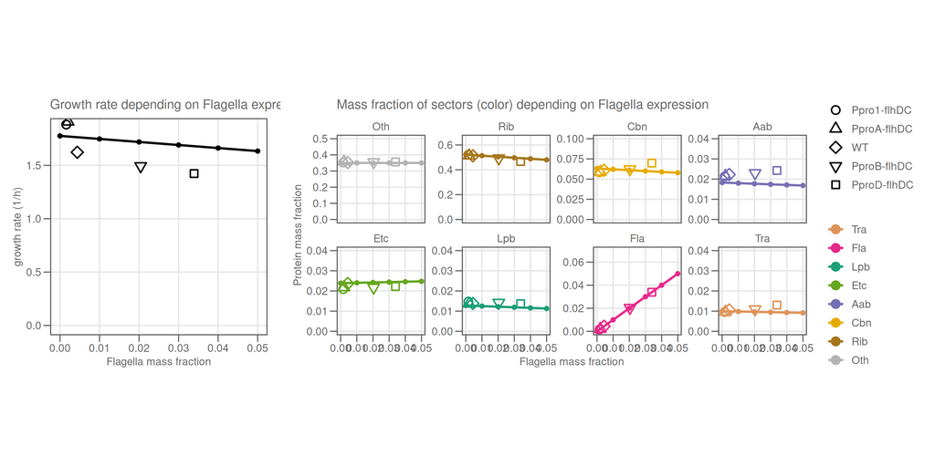

```r
plot_model_strains <- ggarrange(
  ncol = 2, widths = c(0.3, 0.7),
  df_model_sublim %>%
    filter(variable == "a", sector_short == "Rib", time == selected_time) %>%
    ggplot(aes(x = flagella, y = mu)) +
    geom_line() +
    geom_point(size = 1) +
    geom_point(
      data = filter(df_overlay, sector_short == "Rib", mutant %in% mutants_sorted[2:6]),
      mapping = aes(shape = mutant),
      size = 3
    ) +
    custom_theme() +
    scale_color_manual(values = rev(custom_colors)) +
    scale_shape_manual(values = c(1, 2, 5, 6, 22, 12)) +
    coord_cartesian(ylim = c(0, 1.85)) +
    labs(
      title = "Growth rate depending on Flagella expression",
      x = "Flagella mass fraction",
      y = "growth rate (1/h)"
    ) +
    theme(legend.position = "none", aspect.ratio = 1),
  df_model_sublim %>%
    filter(variable == "a", time == selected_time) %>%
    ggplot(aes(x = flagella, y = value, color = fct_rev(sector_short))) +
    geom_line() +
    geom_point(size = 1) +
    geom_point(
      data = filter(df_overlay, mutant %in% mutants_sorted[2:6]),
      mapping = aes(shape = mutant),
      size = 3
    ) +
    custom_theme() +
    scale_color_manual(values = rev(custom_colors)) +
    scale_shape_manual(values = c(1, 2, 5, 6, 22, 12)) +
    labs(
      title = "Mass fraction of sectors (color) depending on Flagella expression",
      x = "Flagella mass fraction",
      y = "Protein mass fraction"
    ) +
    theme(legend.position = "right", aspect.ratio = 1) +
    facet_wrap(~sector_short, ncol = 4, scales = "free_y") +
    ggh4x::facetted_pos_scales(y = list_y_lims)
)

save_plot(plot_model_strains, width = 12, height = 6)
print(plot_model_strains)
```

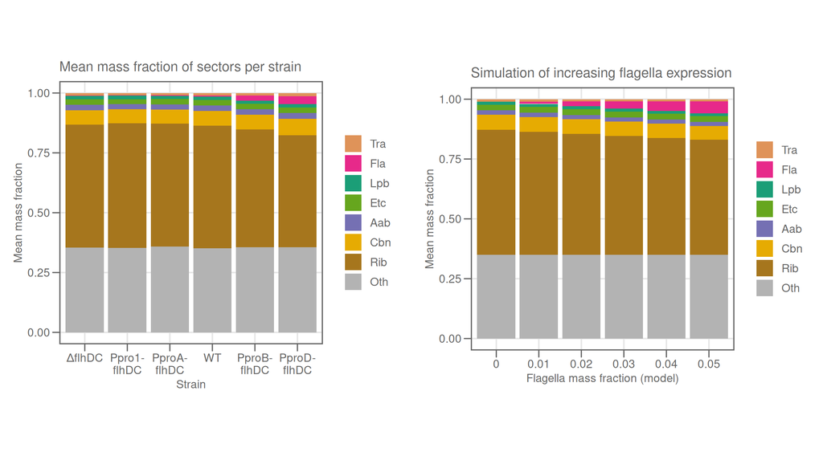

```r
plot_mass_frac_bars <- df_mass_frac %>%
  filter(mutant %in% mutants_sorted[1:6]) %>%
  group_by(mutant, sector_short) %>%
  summarize(
    .groups = "drop",
    mean_mass_fraction = mean(mass_fraction, na.rm = TRUE),
    sd_mass_fraction = sd(mass_fraction, na.rm = TRUE)
  ) %>%
  mutate(mutant = factor(linebreak(mutant), linebreak(mutants_sorted))) %>%
  ggplot(aes(x = mutant, y = mean_mass_fraction, fill = fct_rev(sector_short))) +
  geom_bar(stat = "identity", position = "stack") +
  custom_theme() +
  scale_fill_manual(values = rev(custom_colors)) +
  labs(
    title = "Mean mass fraction of sectors per strain",
    x = "Strain",
    y = "Mean mass fraction",
    fill = "Sector"
  ) +
  theme(legend.position = "right", aspect.ratio = 1)

plot_mass_frac_bars_model <- df_model_sublim %>%
  filter(variable == "a", time == selected_time) %>%
  ggplot(aes(x = factor(flagella), y = value, fill = fct_rev(sector_short))) +
  geom_bar(stat = "identity", position = "stack") +
  custom_theme() +
  scale_fill_manual(values = rev(custom_colors)) +
  labs(
    title = "Simulation of increasing flagella expression",
    x = "Flagella mass fraction (model)",
    y = "Mean mass fraction",
    fill = "Sector"
  ) +
  theme(legend.position = "right", aspect.ratio = 1)

plot_model_strains_bars <- ggarrange(
  ncol = 2,
  plot_mass_frac_bars,
  plot_mass_frac_bars_model
)

save_plot(plot_model_strains_bars, width = 10, height = 5.5)
print(plot_model_strains_bars)
```

- the following figure shows the same information but with a pie chart instead

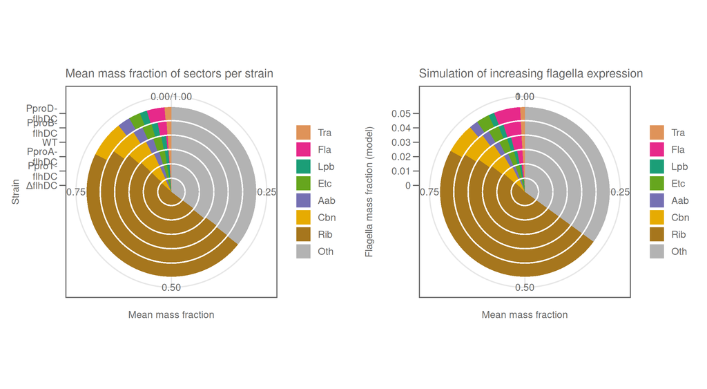

```r
plot_model_strains_pie <- ggarrange(
  ncol = 2, align = "hv",
  plot_mass_frac_bars +
    coord_polar(theta = "y"),
  plot_mass_frac_bars_model +
    coord_polar(theta = "y")
)

save_plot(plot_model_strains_pie, width = 10, height = 5.5)
print(plot_model_strains_pie)
```

- we can also plot ribosome and flagella mass fraction specifically
- plot it versus growth rate, as overlay of model predictions and experimental data
- the result is not as convincing as the model captures the overall trend but underestimates the growth rate changes of the mutants

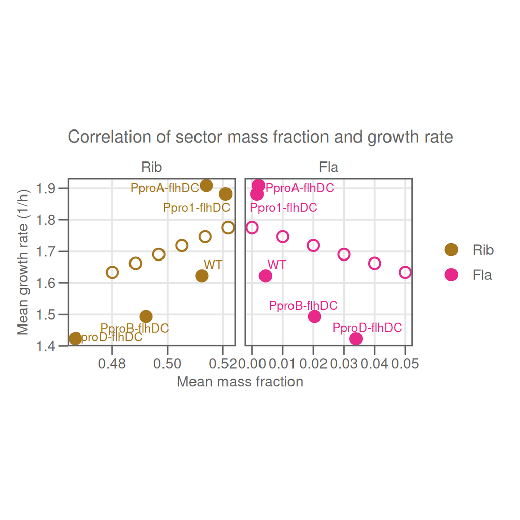

```r
df_model_ribfla <- df_mass_frac %>%
  group_by(mutant, sector_short) %>%
  summarize(
    mean_mass_fraction = mean(mass_fraction, na.rm = TRUE),
    mean_growth_rate = mean(mean_growth_rate, na.rm = TRUE),
    .groups = "drop"
  ) %>%
  filter(sector_short %in% c("Rib", "Fla")) %>%
  filter(mutant %in% mutants_sorted[2:6]) %>%
  bind_rows(df_model_sublim %>%
    filter(variable == "a", time == selected_time, sector_short %in% c("Rib", "Fla")) %>%
    select(flagella, mu, sector_short, value) %>%
    mutate(mutant = "") %>%
    rename(mean_mass_fraction = value, mean_growth_rate = mu)
  )

plot_mass_vs_mu_model <- df_model_ribfla %>%
  ggplot(aes(x = mean_mass_fraction, y = mean_growth_rate, color = sector_short, shape = mutant == "")) +
  geom_point(size = 3) +
  ggrepel::geom_text_repel(aes(label = mutant, color = sector_short), size = 3) +
  custom_theme() +
  scale_shape_manual(values = c(19, 1), guide = "none") +
  scale_color_manual(values = custom_colors[c(2, 7)]) +
  labs(
    title = "Correlation of sector mass fraction and growth rate",
    x = "Mean mass fraction",
    y = "Mean growth rate (1/h)",
    color = "Sector"
  ) +
  theme(legend.position = "right", aspect.ratio = 1) +
  facet_wrap(~sector_short, ncol = 2, scales = "free_x")

save_plot(plot_mass_vs_mu_model, width = 8, height = 5)
print(plot_mass_vs_mu_model)
```

### Simulated vs experimental protein allocation for ribosomes

- this plot shows a more detailed view on the anti-correlation of flagella and ribosome mass
- the model captures the trend quite accurately, but the experimental data show an even stronger decline of ribosomal mass

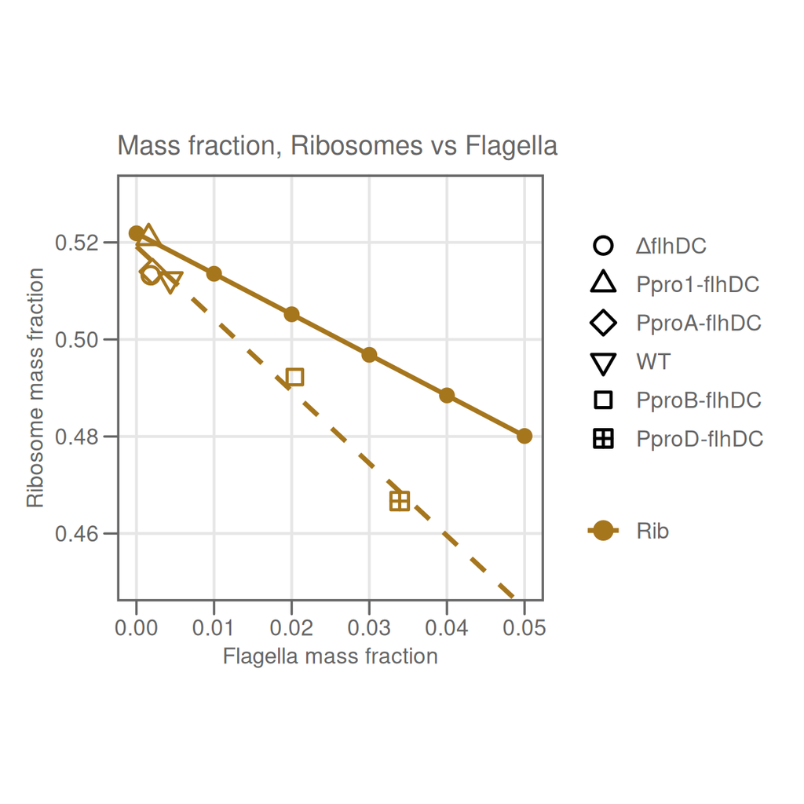

```r
plot_model_rib <- df_model_sublim %>%
  filter(variable == "a", time == selected_time, sector_short == "Rib") %>%
  ggplot(aes(x = flagella, y = value, color = fct_rev(sector_short))) +
  geom_line() +
  geom_point(size = 2) +
  geom_point(
    data = filter(df_overlay, sector_short == "Rib"),
    mapping = aes(shape = mutant),
    size = 3
  ) +
  # linear model fit to the experimental data points
  geom_smooth(
    data = filter(df_overlay, sector_short == "Rib"),
    method = "lm", se = FALSE, linetype = "dashed", linewidth = 1, fullrange = TRUE
  ) +
  custom_theme() +
  scale_color_manual(values = custom_colors[2]) +
  scale_shape_manual(values = c(1, 2, 5, 6, 22, 12)) +
  coord_cartesian(ylim = c(0.45, 0.53)) +
  labs(
    title = "Mass fraction, Ribosomes vs Flagella",
    x = "Flagella mass fraction",
    y = "Ribosome mass fraction"
  ) +
  theme(legend.position = "right", aspect.ratio = 1)

save_plot(plot_model_rib, width = 5, height = 5)
print(plot_model_rib)
```

### Protein cost vs. rotational cost of flagella

The model also allows to investigate the **trade-off between growth rate and motility** in more detail. Essentially, flagella expression is costly and reduces growth rate in a significant way. Therefore, flagella must confer a fitness advantage to bacteria: the ability to move in (complex) environments. In the next section we investigate if **protein cost or energy cost** (ATP driving the rotational movement) is more significant.

```r
df_model_rotation <- read_model_results(
  list.files("../../results/salmonella/rotation", pattern = ".csv", full.names = TRUE)
) %>%
  mutate(energy_cost = str_extract(simulation, "(no_)?ATP")) %>%
  mutate(energy_cost = ifelse(energy_cost == "no_ATP", "without ATP cost\n(no rotation)", "with ATP cost\n(rotation)"))
```

- in addition to the modeling results for simulated flagella expression, we can also overlay experimental data from flagella mutants
- particularly interesting are assembly mutants which produce flagella without the capacity to rotate and to hydrolyze ATP as energy donor
- hence it is possible to separate protein cost from energy cost and see if growth rate of these strains correspond to simulated results

```r
df_rotation_mutants <- df_mass_frac %>%
  filter(mutant %in% mutants_sorted[c(1, 7, 8)]) %>%
  select(matches("mutant|growth|doubling")) %>%
  distinct()
```

- first we prepare a combined data frame for modeling and experimental results (rotation-data only)

```r
df_rotation_combined <- bind_rows(
  df_model_rotation %>%
    filter(
      variable == "a", time == selected_time,
      sector_short == "Rib", flagella %in% c(0.00, 0.05)
    ) %>%
    select(flagella, mu, energy_cost) %>%
    mutate(type = "model") %>%
    filter(!(flagella == 0 & energy_cost == "with ATP cost\n(rotation)")) %>%
    mutate(
      cost = ifelse(mu == max(mu), "without ATP/protein cost\n(no flagellum)", energy_cost),
      mu_sd = 0,
      mutant = paste0("Fla=", flagella * 100, "%"),
      mutant = ifelse(str_starts(cost, "without"), paste(mutant, "R-"), paste(mutant, "R+"))
    ) %>%
    select(type, mutant, cost, mu, mu_sd),
  df_rotation_mutants %>%
    rename(mu = mean_growth_rate, mu_sd = sd_growth_rate) %>%
    select(mutant, mu, mu_sd) %>%
    mutate(
      cost = case_when(
        mutant == "ΔflhDC" ~ "without ATP/protein cost\n(no flagellum)",
        mutant == "WT-(fliC ON)" ~ "with ATP cost\n(rotation)",
        mutant == "motB-D33N" ~ "without ATP cost\n(no rotation)"
      ),
      mutant = linebreak(mutant),
      type = "experiment"
    ) %>%
    select(type, mutant, cost, mu, mu_sd)
)

df_rotation_combined <- df_rotation_combined %>%
  group_by(type) %>%
  arrange(type, mu) %>%
  mutate(penalty = (max(mu) - mu) / max(mu) * 100)
```

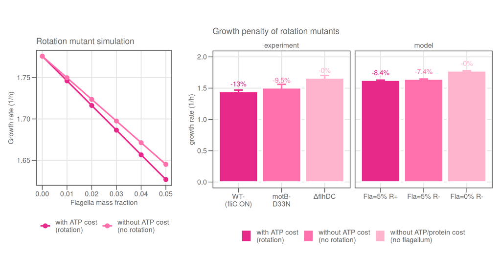

```r
plot_model_rotation <- df_model_rotation %>%
  filter(variable == "a", time == selected_time, sector_short == "Rib") %>%
  ggplot(aes(x = flagella, y = mu, color = energy_cost)) +
  geom_line() +
  geom_point(size = 2) +
  custom_theme(legend.position = "bottom", aspect.ratio = 1) +
  scale_color_manual(values = c(custom_colors[7], lighten(custom_colors[7], 0.3))) +
  labs(
    title = "Rotation mutant simulation",
    x = "Flagella mass fraction",
    y = "Growth rate (1/h)",
    color = "Energy cost"
  )

plot_mutants_rotation <- df_rotation_combined %>%
  mutate(mutant = fct_inorder(mutant)) %>%
  ggplot(aes(
    x = mutant, y = mu,
    color = cost, fill = cost,
    label = paste0("-", round(penalty, 1), "%")
  )) +
  geom_col(position = "dodge", color = "white") +
  geom_errorbar(aes(ymin = mu - mu_sd, ymax = mu + mu_sd), position = position_dodge(width = 0.01), width = 0.2, show.legend = FALSE) +
  geom_text(position = position_dodge(width = 0.01), vjust = -1.0, size = 3.5, show.legend = FALSE) +
  scale_fill_manual(values = c(custom_colors[7], lighten(custom_colors[7], 0.3), lighten(custom_colors[7], 0.6))) +
  scale_color_manual(values = c(custom_colors[7], lighten(custom_colors[7], 0.3), lighten(custom_colors[7], 0.6))) +
  facet_wrap(~type, scales = "free_x") +
  custom_theme(legend.position = "bottom", aspect.ratio = 1) +
  coord_cartesian(ylim = c(0.0, 2.0)) +
  labs(
    title = "Growth penalty of rotation mutants",
    x = "",
    y = "growth rate (1/h)",
    fill = "Energy cost"
  )

plot_rotation_penalty <- ggarrange(
  ncol = 2, widths = c(0.36, 0.64),
  plot_model_rotation,
  plot_mutants_rotation
)

save_plot(plot_rotation_penalty, width = 10, height = 5.5)
print(plot_rotation_penalty)
```

## Dynamic simulation of growth-motility trade-off

- experimental data shows that flagella confer a fitness advantage by moving inside a complex or viscous medium
- the following section shows simulations of a **dynamic model**, where bacterial movement upwards a substrate gradient is simulated
- the bacteria can, by optimizing swimming speed, move towards higher substrate concentration and increase growth and maximal final biomass
- first step is to import data for the simulated gradient, and the simulation results

```r
df_model_gradient <- read_csv(
  "../../results/salmonella/swimming/8500/substrate_gradient.csv"
)

df_model_swimming <- read_model_results(
  list.files(
    path = "../../results/salmonella/swimming/8500",
    pattern = "dynamic_flag_[0-9]\\.[0-9]+\\.csv",
    full.names = TRUE
  )
)
```

- the substrate gradient is simulated using a classic diffusion model for glucose from Crank J, The Mathematics of Diffusion, Oxford University Press, 1979.
- the substrate has an initial concentration of 5 mM, and diffusion time of 3 h
- for simplicity, the gradient is not moving over simulation time
- the total distance analyzed is 8500 μm

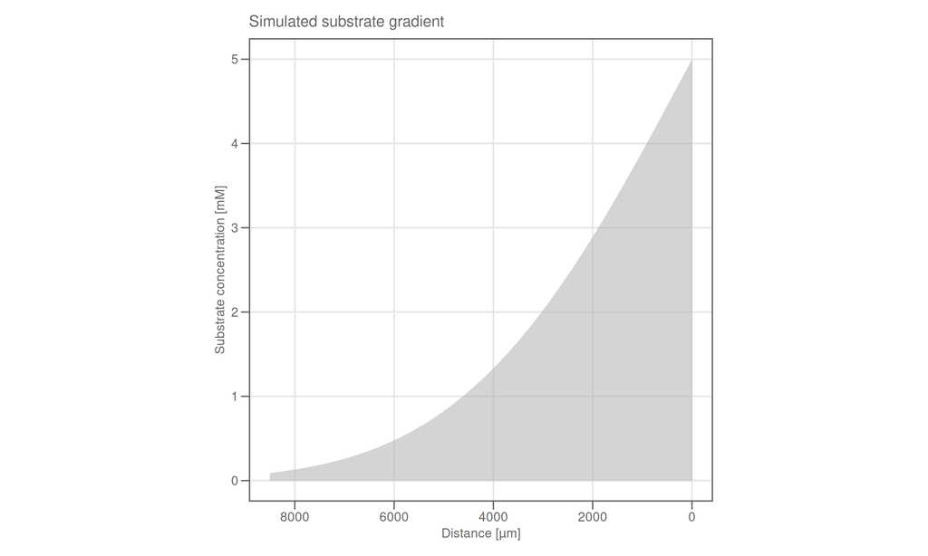

```r
plot_model_gradient <- ggplot(df_model_gradient, aes(x = dist_um, y = substrate_mM)) +
  geom_area(fill = "darkgrey", alpha = 0.5) +
  custom_theme() +
  lims(x = c(max(df_model_gradient$dist_um), 0)) +
  labs(
    title = "Simulated substrate gradient",
    x = "Distance [µm]",
    y = "Substrate concentration [mM]"
  ) +
  theme(legend.position = "right", aspect.ratio = 1)

save_plot(plot_model_gradient, width = 4.5, height = 4.5)
print(plot_model_gradient)
```

- bacteria can travel faster depending on flagella expression
- more flagella means faster initial speed and thus covering a larger distance
- but more flagella also means lower final growth rate due to additional protein/energy cost
- the central question is, what amount of flagella is optimal for travelling, without compromising growth too much?

First, we look at central properties of the cell when simulating swimming with increasing amount of flagella expression (0-5% of proteome mass):

- swimming speed (probaly also rate of flagellum),
- distance travelled
- growth rate
- final biomass (derived from growth rate over time: `Δbm/Δt = mu[t] * bm[t]`)

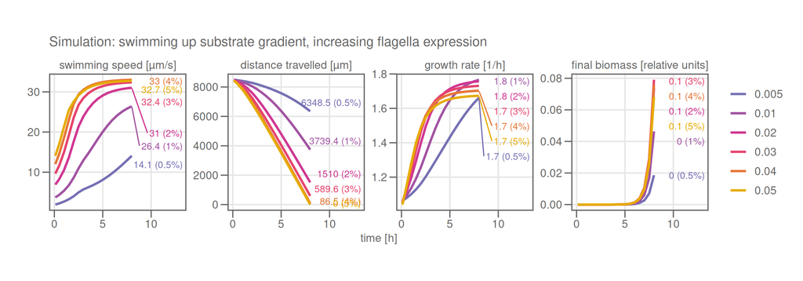

```r
calculate_biomass <- function(mu, bm_start = 1) {
  bm <- bm_start
  bm_final <- c()
  for (i in mu) {
    bm <- bm + i * bm
    bm_final <- append(bm_final, bm)
  }
  return(bm_final)
}

df_model_swimsummary <- df_model_swimming %>%
  filter(variable == "a", sector_short == "Rib") %>%
  select(time, flagella, v_swim, distance, mu) %>%
  group_by(flagella) %>%
  mutate(biomass = calculate_biomass(mu) * 1e-8) %>%
  pivot_longer(cols = v_swim:biomass) %>%
  mutate(name = case_when(
    name == "v_swim" ~ "swimming speed [µm/s]",
    name == "distance" ~ "distance travelled [µm]",
    name == "mu" ~ "growth rate [1/h]",
    name == "biomass" ~ "final biomass [relative units]"
  ) %>% fct_inorder()) %>%
  ungroup()

plot_model_swimming_props <- df_model_swimsummary %>%
  ggplot(aes(x = time, y = value, color = factor(flagella))) +
  geom_line() +
  geom_text_repel(
    data = . %>% group_by(name, flagella) %>% slice_tail(n = 1),
    aes(label = paste0(round(value, 1), " (", flagella * 100, "%)")),
    size = 3, show.legend = FALSE, nudge_x = 5.0,
    direction = "y", hjust = 0, min.segment.length = 2.0
  ) +
  custom_theme() +
  scale_color_manual(
    values = colorRampPalette(custom_colors[c(4, 7, 3)])(length(unique(df_model_swimming$flagella)))
  ) +
  labs(
    title = "Simulation: swimming up substrate gradient, increasing flagella expression",
    x = "time [h]",
    y = ""
  ) +
  theme(legend.position = "right", aspect.ratio = 1) +
  facet_wrap(~name, ncol = 4, scales = "free_y")

save_plot(plot_model_swimming_props, width = 10, height = 3.5)
print(plot_model_swimming_props)
```

- to break down the results to the most concise representation, we plot swimming distance on the x-axis overlaid on substrate the gradient
- then additionally growth rate over time as line plot and final biomass as bar chart

```r
df_swimming_dist <- df_model_swimsummary %>%
  filter(time == max(time), name == "distance travelled [µm]") %>%
  mutate(
    dist_um = 8500 - value,
    flagella_pct = flagella * 100
  )

plot_swimming_dist <- df_swimming_dist %>%
  ggplot(aes(x = dist_um, y = flagella_pct, color = factor(flagella))) +
  geom_segment(aes(x = dist_um, xend = 0, y = flagella_pct, yend = flagella_pct)) +
  geom_point() +
  geom_area(
    data = df_model_gradient,
    aes(x = 8500 - dist_um, y = substrate_mM),
    inherit.aes = FALSE,
    fill = "darkgrey", alpha = 0.5
  ) +
  custom_theme() +
  scale_color_manual(
    values = colorRampPalette(custom_colors[c(4, 7, 3)])(length(unique(df_model_swimming$flagella)))
  ) +
  scale_y_continuous(
    name = "flagella mass fraction [%]",
    breaks = sort(unique(df_swimming_dist$flagella_pct)),
    sec.axis = sec_axis(~., name = "Substrate concentration [mM]")
  ) +
  labs(
    title = "Swimming up substrate gradient",
    x = "distance travelled [µm]",
    y = "flagella mass fraction [%]"
  ) +
  coord_cartesian(xlim = c(0, 8500)) +
  theme(legend.position = "none", aspect.ratio = 1)
```

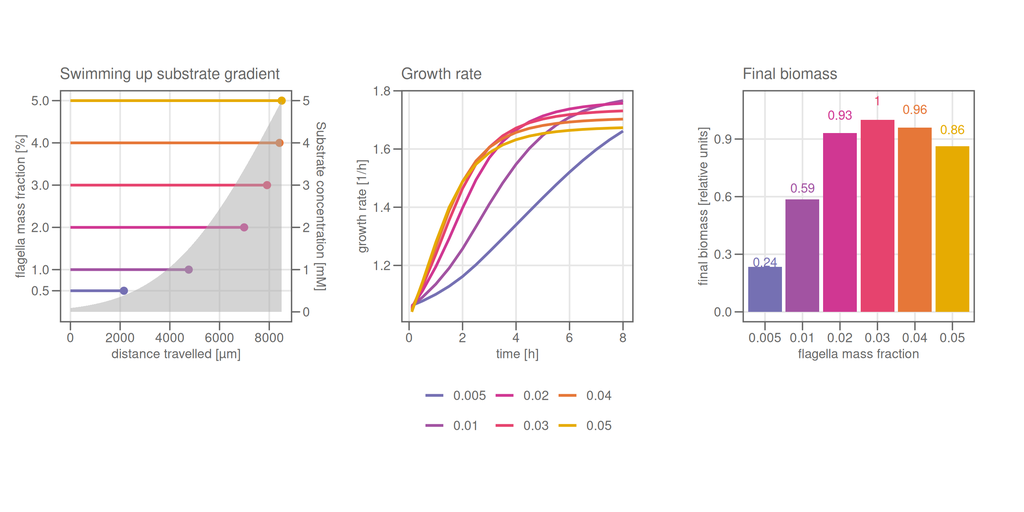

```r
plot_swimming_mu <- df_model_swimsummary %>%
  filter(name == "growth rate [1/h]") %>%
  ggplot(aes(x = time, y = value, color = factor(flagella))) +
  geom_line() +
  custom_theme(legend.position = "bottom", aspect.ratio = 1) +
  scale_color_manual(
    values = colorRampPalette(custom_colors[c(4, 7, 3)])(length(unique(df_model_swimming$flagella)))
  ) +
  labs(
    title = "Growth rate",
    x = "time [h]",
    y = "growth rate [1/h]"
  )

plot_swimming_biomass <- df_model_swimsummary %>%
  filter(name == "final biomass [relative units]", time == max(time)) %>%
  mutate(bm = value / max(value)) %>%
  ggplot(aes(x = factor(flagella), y = bm, fill = factor(flagella))) +
  geom_col() +
  geom_text(
    aes(label = round(bm, 2), color = factor(flagella)),
    position = position_stack(vjust = 1.1), size = 3.5, show.legend = FALSE
  ) +
  custom_theme(legend.position = "none", aspect.ratio = 1) +
  scale_fill_manual(
    values = colorRampPalette(custom_colors[c(4, 7, 3)])(length(unique(df_model_swimming$flagella)))
  ) +
  scale_color_manual(
    values = colorRampPalette(custom_colors[c(4, 7, 3)])(length(unique(df_model_swimming$flagella)))
  ) +
  labs(
    title = "Final biomass",
    x = "flagella mass fraction",
    y = "final biomass [relative units]"
  )

plot_swimming_summary <- ggarrange(
  ncol = 3, align = "hv",
  plot_swimming_dist,
  plot_swimming_mu,
  plot_swimming_biomass
)
save_plot(plot_swimming_summary, width = 11, height = 5.5)
print(plot_swimming_summary)
```

Finally, we look at the mass fraction of the different sectors over time.

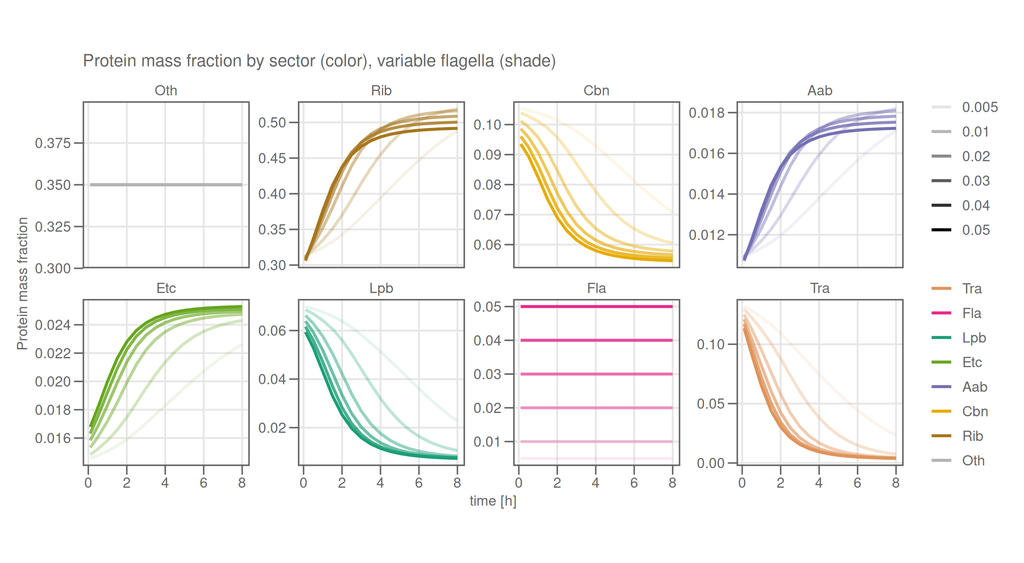

```r
plot_model_swimming_enz <- df_model_swimming %>%
  filter(variable == "a") %>%
  ggplot(aes(x = time, y = value, color = fct_rev(sector_short), alpha = factor(flagella))) +
  geom_line() +
  custom_theme() +
  scale_color_manual(values = rev(custom_colors)) +
  labs(
    title = "Protein mass fraction by sector (color), variable flagella (shade)",
    x = "time [h]",
    y = "Protein mass fraction"
  ) +
  theme(legend.position = "right", aspect.ratio = 1) +
  facet_wrap(~sector_short, ncol = 4, scales = "free_y")

save_plot(plot_model_swimming_enz, width = 10, height = 5.5)
print(plot_model_swimming_enz)
```